# SNP and CNV Analysis using beadArraySNP

Carlos Ramirez

August 25, 2017

En este reporte incluyo el importe de los datos de SNPs obtenidos de los beadarray de la plataforma Illumina GoldenGate a R mediante el uso del paquete beadArraySNP.

## Tipos de datos proveídos por Illumina

### El archivo .opa

El archivo .opa contiene información del tipo de SNP analizado, los oligos usados, ubicación cromosómica y detalles de anotación del organismo como se muestra en el siguiente output.

```r
pathOpa <- "~/dataBases/GoldenGate_U15_025 AT/GenomeStudio/GS0014416-OPA.opa"
readLines(pathOpa,n = 13)
```

```
##  [1] "\xa9 Illumina, Inc. 2004"
##  [2] "[Heading]"
##  [3] "OPA,GS0014416-OPA"
##  [4] "Test Version,10104574"
##  [5] "Test Version Name,10104574"
##  [6] "Test Name,10104574"
##  [7] "Bundle Index,1 of 1"
##  [8] "SNP Position,1"
##  [9] "Assay Format,Golden Gate"
## [10] "Date Manufactured,5/12/15"
## [11] "Loci Count,1536 of 1536"
## [12] "Comment,"
## [13] "Ilmn ID,Name,oligo1,oligo2,oligo3,IllumiCode name,Illumicode Seq,Ilmn Strand,SNP,CHR,Ploidy,Species,MapInfo,TopGenomicSeq,CustomerStrand"
```

### Archivo SampleSheet.csv

El archivo SampleSheet_ID.csv contiene información acerca de los IDs de cada beadArray y su posición en el arreglo. En la [documentación](https://bioconductor.org/packages/devel/bioc/vignettes/beadarraySNP/inst/doc/beadarraySNP.pdf) de beadArraySNP este archivo corresponde al archivo 4samples_opa4.csv.

La información incluida en SampleSheet_ID.csv se muestra a continuación.

```r
pathSampleSheet <- "~/dataBases/GoldenGate_U15_025 AT/GenomeStudio/SampleSheet_ID.csv"
readLines(pathSampleSheet,n=13)
```

```
##  [1] "[Header],,,,"
##  [2] "INVESTIGATOR NAME,BeadStudio User,,,"
##  [3] "PROJECT NAME,U15_025,,,"
##  [4] "EXPERIMENT NAME,U15_025,,,"
##  [5] "DATE,05/01/2017 01:03:30 p.m.,,,"
##  [6] "[Manifests],,,,"
##  [7] "A,GS0014416-OPA,,,"
##  [8] "[Data],,,,"
##  [9] "Sample_ID,SentrixBarcode_A,SentrixPosition_A,Path,Aux"
## [10] "AU_118_1,101035450001,R01C01,\\\\192.168.102.41\\UMi-2\\ILLUMINA\\Servicios_2017\\DrNicolini\\U15_025\\101035450001,0"
## [11] "AU_103_1,101035450001,R02C01,\\\\192.168.102.41\\UMi-2\\ILLUMINA\\Servicios_2017\\DrNicolini\\U15_025\\101035450001,0"
## [12] "1004,101035450001,R03C01,\\\\192.168.102.41\\UMi-2\\ILLUMINA\\Servicios_2017\\DrNicolini\\U15_025\\101035450001,0"
## [13] "AU_126_1,101035450001,R04C01,\\\\192.168.102.41\\UMi-2\\ILLUMINA\\Servicios_2017\\DrNicolini\\U15_025\\101035450001,0"
```

### Importe de datos a BeadArraySNP

El siguiente código es un intento por cargar los datos a beadArraySNP basado en las siguientes [notas](https://support.bioconductor.org/p/25142/), [véase también](https://rdrr.io/bioc/beadarraySNP/man/read.SnpSetIllumina.html).

```r
library(beadarraySNP)

## rutas a archivos locales
path2SampleMap <- "~/scripts/autismProject/data/Sample_Map.txt"
path2report <- "~/scripts/autismProject/data/autism_FinalReport.txt"

## Cargando datos
SNPData <- read.SnpSetIllumina(Sample_Map2Samplesheet(path2SampleMap),
                               reportfile = path2report)
```

```r
slotNames(SNPData)
```

```
## [1] "assayData"         "phenoData"         "featureData"
## [4] "experimentData"    "annotation"        "protocolData"
## [7] ".__classVersion__"
```

```r
names(assayData(SNPData))
```

```
## [1] "call"            "callProbability" "G"               "R"
## [5] "Sample Index"    "Theta"           "Rad"             "X"
## [9] "Y"
```

### Exploración del objeto SNPData

```r
assayData(SNPData)$call[1:3,1:5]
```

```
##            101035450001_R01C01 101035450001_R01C02 101035450001_R01C03
## rs10013071 "-"                 "-"                 "-"
## rs10013254 "-"                 "-"                 "-"
## rs10029775 "-"                 "-"                 "-"
##            101035450001_R01C04 101035450001_R02C01
## rs10013071 "-"                 "-"
## rs10013254 "-"                 "-"
## rs10029775 "-"                 "-"
```

Las asignaciones alélicas están vacías. PROBLEMA. En el [training](https://support.illumina.com/array/array_software/genomestudio/training.html) de Illumina como asignar valores AA, AB, etc.. de los valores theta. Sin embargo en los datos input proveídos por Illumina en el campo call los valores de la matriz son A, B o H. H tal vez refiere a los heterocigotos.

```r
assayData(SNPData)$G[1:3,1:5]
```

```
##            101035450001_R01C01 101035450001_R01C02 101035450001_R01C03
## rs10013071               12723               11595                1261
## rs10013254                1774               10465                1993
## rs10029775                1494                1172                1371
##            101035450001_R01C04 101035450001_R02C01
## rs10013071                7993                6862
## rs10013254                1964               10683
## rs10029775                7697                1404
```

```r
assayData(SNPData)$R[1:3,1:5]
```

```
##            101035450001_R01C01 101035450001_R01C02 101035450001_R01C03
## rs10013071                1233                1077                8978
## rs10013254               11759                6566               10144
## rs10029775               17689               17136               14390
##            101035450001_R01C04 101035450001_R02C01
## rs10013071                4356                1717
## rs10013254               11772                6084
## rs10029775               10033               11211
```

```r
assayData(SNPData)$Theta[1:3,1:5]
```

```
##            101035450001_R01C01 101035450001_R01C02 101035450001_R01C03
## rs10013071               0.007               0.007               0.985
## rs10013254               0.974               0.370               0.951
## rs10029775               0.996               1.000               0.991
##            101035450001_R01C04 101035450001_R02C01
## rs10013071               0.348               0.116
## rs10013254               0.960               0.381
## rs10029775               0.661               0.990
```

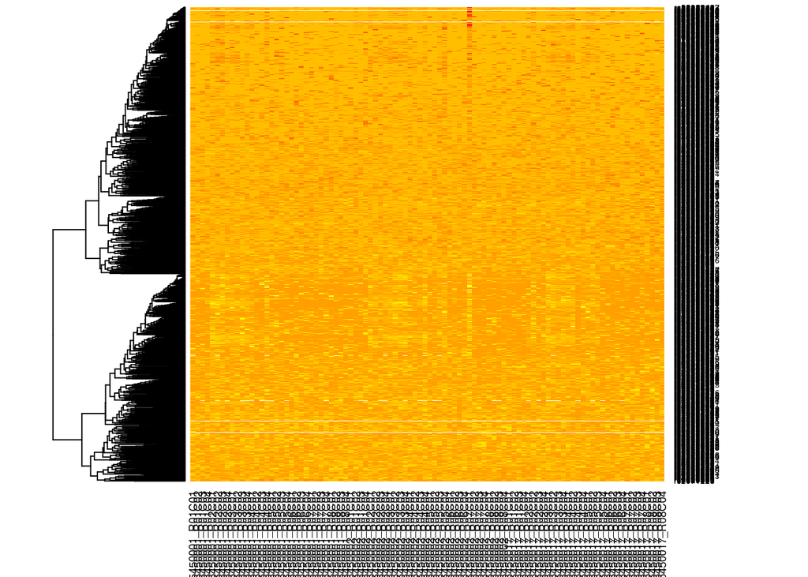

```r
heatmap(assayData(SNPData)$Theta,Colv = NA)
```